# Plant Allometry Data Source Inventory

# 3 Source profiles

## 3.1 BAAD — Biomass And Allometry Database

```r
library(baad.data)
baad <- baad.data::baad_data()
dat_baad <- baad$data

kable(data.frame(
  Metric = c("Total individuals","Species","Studies","Lat/lon coverage",
             "Height (h.t) n","Total biomass (m.to) n","Leaf mass (m.lf) n",
             "Stem mass (m.st) n","Root mass (m.rt) n","Leaf area (a.lf) n"),
  Value  = c(
    format(nrow(dat_baad), big.mark=","),
    length(unique(dat_baad$speciesMatched)),
    length(unique(dat_baad$studyName)),
    paste0(sum(!is.na(dat_baad$latitude)), " (", round(100*mean(!is.na(dat_baad$latitude))), "%)"),
    sum(!is.na(dat_baad$h.t)),
    sum(!is.na(dat_baad$m.to)),
    sum(!is.na(dat_baad$m.lf)),
    sum(!is.na(dat_baad$m.st)),
    sum(!is.na(dat_baad$m.rt)),
    sum(!is.na(dat_baad$a.lf))
  )
), caption = "BAAD profile")
```

BAAD profile

| Metric | Value |
| --- | --- |
| Total individuals | 21,084 |
| Species | 656 |
| Studies | 176 |
| Lat/lon coverage | 21021 (100%) |
| Height (h.t) n | 19586 |
| Total biomass (m.to) n | 8878 |
| Leaf mass (m.lf) n | 17069 |
| Stem mass (m.st) n | 14421 |
| Root mass (m.rt) n | 9061 |
| Leaf area (a.lf) n | 13846 |

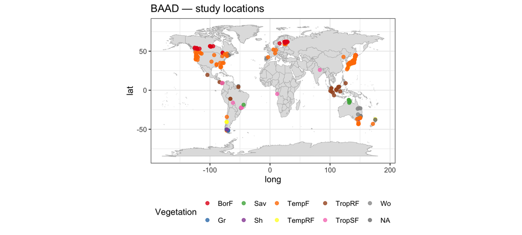

```r
world <- map_data("world")
pts <- dat_baad |> filter(!is.na(latitude), !is.na(longitude)) |>
  distinct(studyName, latitude, longitude, vegetation)
ggplot() +
  geom_polygon(data=world, aes(x=long,y=lat,group=group), fill="grey88", color="grey70", linewidth=0.2) +
  geom_point(data=pts, aes(x=longitude, y=latitude, color=vegetation), alpha=0.8, size=2) +
  coord_fixed(1.3) +
  scale_color_brewer(palette="Set1", na.value="grey50") +
  labs(title="BAAD — study locations", color="Vegetation") +
  theme(legend.position="bottom")
```

## 3.2 Niklas-Enquist Biomass Dataset

```r
ne <- read_csv("data/raw/niklas_enquist/niklas_enquist_biomass_20040122.csv",
  skip=2,
  col_names=c("taxa","citation","footnotes","record_num","age_yr","log_age",
    "height_m","log_height","root_biomass_kg","log_root","stem_biomass_kg","log_stem",
    "leaf_biomass_kg","log_leaf","shoot_biomass_kg","log_shoot","repro_biomass_kg","log_repro",
    "total_biomass_kg","log_total","stem_growth_kgyr","log_stem_growth","leaf_growth_kgyr",
    "log_leaf_growth","root_growth_kgyr","log_root_growth","total_growth_kgyr","log_total_growth"),
  locale=locale(encoding="latin1"), show_col_types=FALSE, skip_empty_rows=TRUE) |>
  mutate(across(-c(taxa,citation,footnotes), as.numeric)) |>
  mutate(across(where(is.numeric), ~ifelse(.==-999, NA_real_, .)))

kable(data.frame(
  Metric = c("Total records","Unique taxa strings","Unique citation sources",
             "Height (m) n","Root biomass (kg) n","Stem biomass (kg) n",
             "Leaf biomass (kg) n","Total biomass (kg) n","Age (yr) n",
             "Growth rate (kg/yr) n","Geographic coordinates","Original source"),
  Value  = c(
    format(nrow(ne), big.mark=","),
    length(unique(ne$taxa)),
    length(unique(ne$citation[!is.na(ne$citation)])),
    sum(!is.na(ne$height_m)),
    sum(!is.na(ne$root_biomass_kg)),
    sum(!is.na(ne$stem_biomass_kg)),
    sum(!is.na(ne$leaf_biomass_kg)),
    sum(!is.na(ne$total_biomass_kg)),
    sum(!is.na(ne$age_yr)),
    sum(!is.na(ne$total_growth_kgyr)),
    "None — inferred from taxon/citation text",
    "Cannell (1982) + primary literature (1920s–2003)"
  )
), caption = "Niklas-Enquist biomass dataset profile")
```

Niklas-Enquist biomass dataset profile

| Metric | Value |
| --- | --- |
| Total records | 2,626 |
| Unique taxa strings | 390 |
| Unique citation sources | 359 |
| Height (m) n | 1147 |
| Root biomass (kg) n | 1310 |
| Stem biomass (kg) n | 1252 |
| Leaf biomass (kg) n | 1175 |
| Total biomass (kg) n | 664 |
| Age (yr) n | 1564 |
| Growth rate (kg/yr) n | 1180 |
| Geographic coordinates | None — inferred from taxon/citation text |
| Original source | Cannell (1982) + primary literature (1920s–2003) |

**Geographic note:** The Niklas-Enquist CSV contains no latitude/longitude columns. Geographic origin must be inferred from taxon native ranges or citation text. The map below shows **inferred** origin regions based on keyword parsing of citation journal names and taxon strings — treat as approximate and unverified.

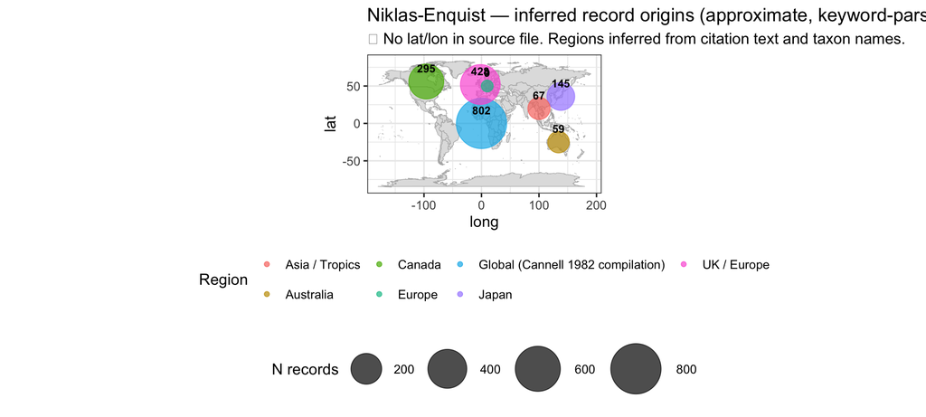

```r
# Infer broad region from citation keywords — explicitly flagged as approximate
ne_geo <- ne |>
  mutate(region_inferred = case_when(
    grepl("Japan|Japanese|Hokkaido|Honshu", citation, ignore.case=TRUE) |
      grepl("japonica|japonis", taxa, ignore.case=TRUE) ~ "Japan",
    grepl("Canada|Canadian|Can\\. J", citation, ignore.case=TRUE) |
      grepl("papyrifera|tremuloides|canadensis", taxa, ignore.case=TRUE) ~ "Canada",
    grepl("Australia|Australian|Snowy Mountains", citation, ignore.case=TRUE) |
      grepl("Eucalyptus|Acacia", taxa, ignore.case=TRUE) ~ "Australia",
    grepl("Germany|German|Harz", citation, ignore.case=TRUE) |
      grepl("sylvatica|sylvestris", taxa, ignore.case=TRUE) &
      grepl("Germany|German|European|Scand", citation, ignore.case=TRUE) ~ "Europe",
    grepl("British|UK|Scotland|England|Wales", citation, ignore.case=TRUE) |
      grepl("Journal of Ecology", citation, ignore.case=TRUE) ~ "UK / Europe",
    grepl("USA|United States|Georgia|Oregon|Michigan|Alaska|Pacific Northwest|Appalachian",
          citation, ignore.case=TRUE) ~ "USA",
    grepl("India|Indian|Gezira|Pakistan|Borneo|Malaysian|Tropical",
          citation, ignore.case=TRUE) ~ "Asia / Tropics",
    grepl("Cannell", citation, ignore.case=TRUE) ~ "Global (Cannell 1982 compilation)",
    TRUE ~ "Unknown / unclassified"
  ))

region_counts <- ne_geo |> count(region_inferred, sort=TRUE)

# Approximate centroids for bubble map
centroids <- data.frame(
  region_inferred = c("Japan","Canada","Australia","Europe","UK / Europe",
                      "USA","Asia / Tropics","Global (Cannell 1982 compilation)","Unknown / unclassified"),
  lon = c(138, -96, 134, 10, -2, -98, 100, 0, NA),
  lat = c(36, 56, -25, 50, 52, 40, 20, 0, NA)
)
plot_df <- region_counts |> left_join(centroids, by="region_inferred") |>
  filter(!is.na(lon))

ggplot() +
  geom_polygon(data=world, aes(x=long,y=lat,group=group), fill="grey88", color="grey70", linewidth=0.2) +
  geom_point(data=plot_df, aes(x=lon, y=lat, size=n, color=region_inferred), alpha=0.7) +
  geom_text(data=plot_df, aes(x=lon, y=lat, label=n), size=3, vjust=-1.2, fontface="bold") +
  scale_size_continuous(range=c(4,18)) +
  coord_fixed(1.3) +
  labs(title="Niklas-Enquist — inferred record origins (approximate, keyword-parsed)",
       subtitle="⚠ No lat/lon in source file. Regions inferred from citation text and taxon names.",
       size="N records", color="Region") +
  theme(legend.position="bottom", legend.box="vertical")
```

## 3.3 Tallo — Global Tree Allometry and Crown Architecture

```r
tallo_path <- file.path(dirname(knitr::current_input(dir = TRUE)),
                        "data/raw/tallo/Tallo.csv")
tallo <- read_csv(tallo_path, show_col_types = FALSE)

kable(data.frame(
  Metric = c("Total records","Records with height","Records with crown radius",
             "Records with all 3 measurements",
             "Unique species","Unique genera","Unique families",
             "Lat/lon coverage","Lat range (°)","Lon range (°)",
             "Source studies","Citation"),
  Value = c(
    format(nrow(tallo), big.mark=","),
    format(sum(!is.na(tallo$height_m)), big.mark=","),
    format(sum(!is.na(tallo$crown_radius_m)), big.mark=","),
    format(sum(!is.na(tallo$stem_diameter_cm) & !is.na(tallo$height_m) &
               !is.na(tallo$crown_radius_m)), big.mark=","),
    format(length(unique(tallo$species[!is.na(tallo$species)])), big.mark=","),
    format(length(unique(tallo$genus[!is.na(tallo$genus)])), big.mark=","),
    format(length(unique(tallo$family[!is.na(tallo$family)])), big.mark=","),
    paste0(nrow(tallo), " (100%)"),
    paste0(round(min(tallo$latitude),1), " to ", round(max(tallo$latitude),1)),
    paste0(round(min(tallo$longitude),1), " to ", round(max(tallo$longitude),1)),
    length(unique(tallo$reference_id)),
    "Jucker et al. (2022) Global Change Biology 28:5254-5268; Zenodo doi:10.5281/zenodo.6637599"
  )
), caption = "Tallo database profile")
```

Tallo database profile

| Metric | Value |
| --- | --- |
| Total records | 498,838 |
| Records with height | 497,335 |
| Records with crown radius | 312,829 |
| Records with all 3 measurements | 311,326 |
| Unique species | 5,162 |
| Unique genera | 1,453 |
| Unique families | 187 |
| Lat/lon coverage | 498838 (100%) |
| Lat range (°) | -51.6 to 69.9 |
| Lon range (°) | -155.3 to 177 |
| Source studies | 69 |
| Citation | Jucker et al. (2022) Global Change Biology 28:5254-5268; Zenodo doi:10.5281/zenodo.6637599 |

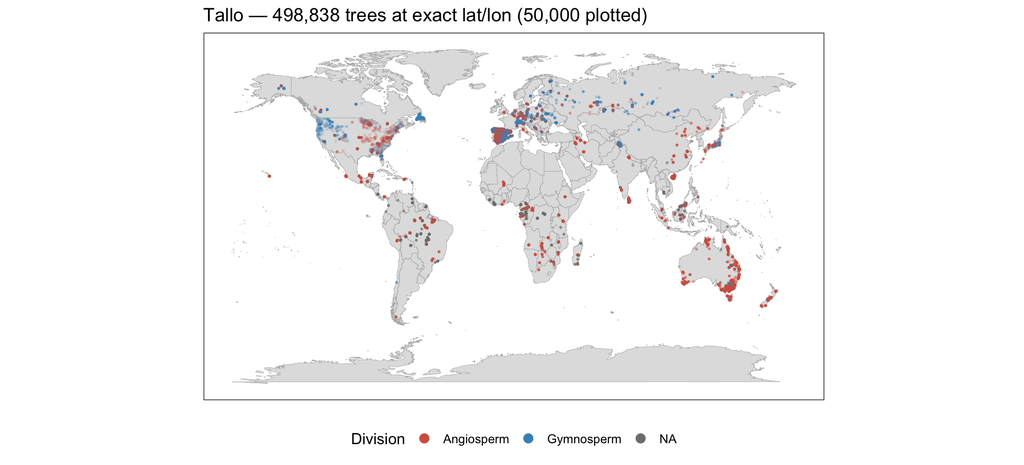

```r
set.seed(42)
tallo_thin <- tallo |> sample_n(min(50000, n()))

ggplot() +
  geom_polygon(data=world, aes(x=long,y=lat,group=group),
               fill="grey88", color="grey70", linewidth=0.15) +
  geom_point(data=tallo_thin,
             aes(x=longitude, y=latitude, color=division),
             alpha=0.15, size=0.4) +
  scale_color_manual(values=c(Angiosperm="#d6604d",Gymnosperm="#4393c3"),
                     na.value="grey50") +
  coord_fixed(1.3) +
  guides(color=guide_legend(override.aes=list(alpha=1,size=3))) +
  labs(title=paste0("Tallo — ", format(nrow(tallo),big.mark=','),
                    " trees at exact lat/lon (50,000 plotted)"),
       color="Division", x=NULL, y=NULL) +
  theme(axis.text=element_blank(), axis.ticks=element_blank(),
        panel.grid=element_blank(), legend.position="bottom")
```

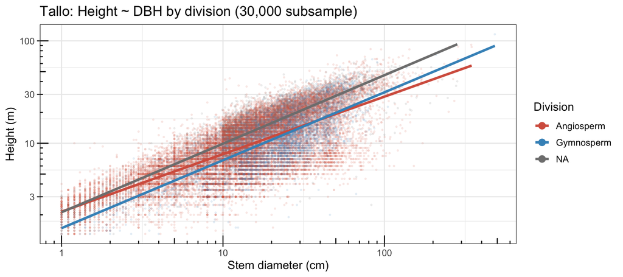

```r
tallo |> filter(!is.na(stem_diameter_cm), !is.na(height_m)) |>
  sample_n(min(30000, n())) |>
  ggplot(aes(x=stem_diameter_cm, y=height_m, color=division)) +
  geom_point(alpha=0.1, size=0.5) +
  geom_smooth(method="lm", linewidth=1.2, se=FALSE) +
  scale_x_log10(labels=comma) + scale_y_log10(labels=comma) +
  annotation_logticks() +
  scale_color_manual(values=c(Angiosperm="#d6604d",Gymnosperm="#4393c3"),
                     na.value="grey50") +
  guides(color=guide_legend(override.aes=list(alpha=1,size=3))) +
  labs(x="Stem diameter (cm)", y="Height (m)",
       title="Tallo: Height ~ DBH by division (30,000 subsample)",
       color="Division")
```

## 3.4 allodb — ForestGEO Allometric Equations

```r
library(allodb)

kable(data.frame(
  Metric = c("Total equations","Source studies","Equations with lat/lon",
             "Primary independent variable","Top dependent variable",
             "DBH range covered","Equation forms (unique)","Geographic scope"),
  Value  = c(
    nrow(equations),
    length(unique(equations$ref_id)),
    sum(!is.na(equations$lat) & !equations$lat %in% c("NRA","NI","")),
    "DBH (also: DRC, basal area)",
    "Total aboveground biomass (AGB)",
    paste0(min(as.numeric(equations$dbh_min_cm[equations$dbh_min_cm!="NRA"&equations$dbh_min_cm!="NI"]), na.rm=TRUE), "–",
           max(as.numeric(equations$dbh_max_cm[equations$dbh_max_cm!="NRA"&equations$dbh_max_cm!="NI"]), na.rm=TRUE), " cm"),
    length(unique(equations$equation_form)),
    "Temperate N. America, E. Asia, Europe; mostly ForestGEO sites"
  )
), caption = "allodb profile")
```

allodb profile

| Metric | Value |
| --- | --- |
| Total equations | 570 |
| Source studies | 55 |
| Equations with lat/lon | 412 |
| Primary independent variable | DBH (also: DRC, basal area) |
| Top dependent variable | Total aboveground biomass (AGB) |
| DBH range covered | 0.1–614 cm |
| Equation forms (unique) | 37 |
| Geographic scope | Temperate N. America, E. Asia, Europe; mostly ForestGEO sites |

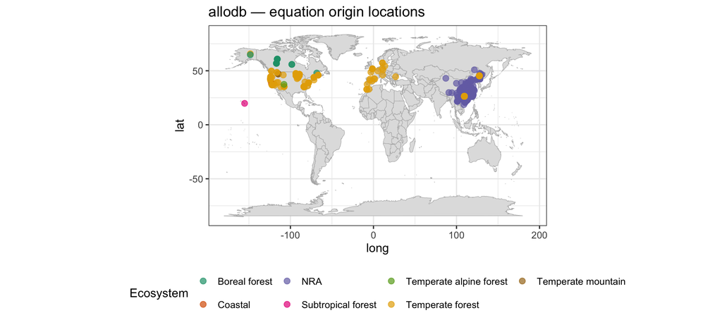

```r
eq_geo <- equations |>
  mutate(lat_num  = suppressWarnings(as.numeric(lat)),
         long_num = suppressWarnings(as.numeric(long))) |>
  filter(!is.na(lat_num), !is.na(long_num), lat_num != 0)

ggplot() +
  geom_polygon(data=world, aes(x=long,y=lat,group=group), fill="grey88", color="grey70", linewidth=0.2) +
  geom_point(data=eq_geo, aes(x=long_num, y=lat_num, color=ecosystem_type), alpha=0.7, size=2.5) +
  coord_fixed(1.3) +
  scale_color_brewer(palette="Dark2", na.value="grey60") +
  labs(title="allodb — equation origin locations", color="Ecosystem") +
  theme(legend.position="bottom")
```

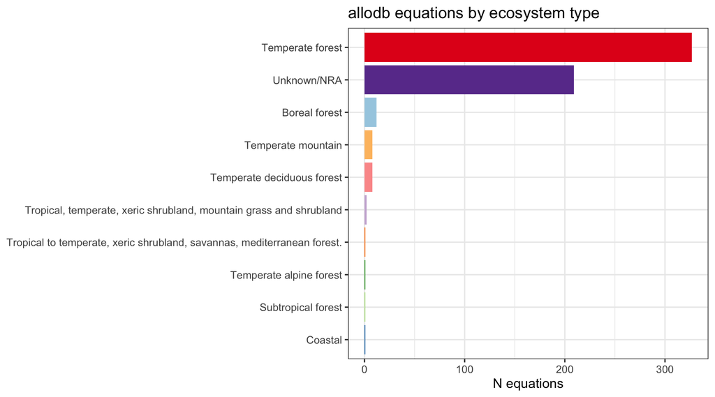

```r
equations |>
  mutate(eco = ifelse(ecosystem_type %in% c("NRA","NI","") | is.na(ecosystem_type),
                      "Unknown/NRA", ecosystem_type)) |>
  count(eco, sort=TRUE) |>
  ggplot(aes(x=reorder(eco,n), y=n, fill=eco)) +
  geom_col(show.legend=FALSE) + coord_flip() +
  scale_fill_brewer(palette="Paired") +
  labs(x=NULL, y="N equations", title="allodb equations by ecosystem type")
```

## 3.5 BIOMASS — Wood Density Database (Zanne et al. 2009 backbone)

```r
library(BIOMASS)

kable(data.frame(
  Metric = c("Total records","Unique species","Families",
             "Wood density range (g/cm³)","Regions covered"),
  Value  = c(
    format(nrow(wdData), big.mark=","),
    length(unique(wdData$species)),
    length(unique(wdData$family)),
    paste0(round(min(wdData$wd,na.rm=TRUE),2), "–", round(max(wdData$wd,na.rm=TRUE),2)),
    length(unique(wdData$region))
  )
), caption = "BIOMASS::wdData (global wood density database) profile")
```

BIOMASS::wdData (global wood density database) profile

| Metric | Value |
| --- | --- |
| Total records | 16,467 |
| Unique species | 4452 |
| Families | 193 |
| Wood density range (g/cm³) | 0.08–1.39 |
| Regions covered | 16 |

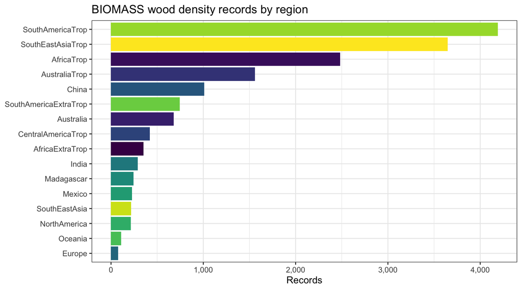

```r
wdData |>
  count(regionId, sort=TRUE) |>
  ggplot(aes(x=reorder(regionId,n), y=n, fill=regionId)) +
  geom_col(show.legend=FALSE) + coord_flip() +
  scale_y_continuous(labels=comma) +
  scale_fill_viridis_d() +
  labs(x=NULL, y="Records", title="BIOMASS wood density records by region")
```

## 3.6 BIOMASS — Height-Diameter paired data (Nouragues, French Guiana)

```r
kable(data.frame(
  Metric = c("Individuals","Species","Location","Variables"),
  Value  = c(nrow(NouraguesHD),
             length(unique(paste(NouraguesHD$genus, NouraguesHD$species))),
             "Nouragues Reserve, French Guiana (~4°N, 53°W)",
             "DBH (cm), height (m), genus, species, lat, lon")
), caption = "BIOMASS::NouraguesHD profile")
```

BIOMASS::NouraguesHD profile

| Metric | Value |
| --- | --- |
| Individuals | 1051 |
| Species | 196 |
| Location | Nouragues Reserve, French Guiana (~4°N, 53°W) |
| Variables | DBH (cm), height (m), genus, species, lat, lon |

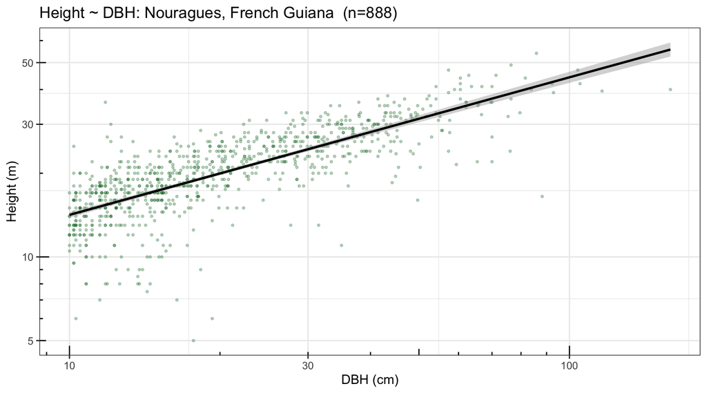

```r
NouraguesHD |>
  filter(D > 0, H > 0) |>
  ggplot(aes(x=D, y=H)) +
  geom_point(alpha=0.3, size=0.8, color="#1b7837") +
  geom_smooth(method="lm", color="black", linewidth=1) +
  scale_x_log10(labels=comma) + scale_y_log10(labels=comma) +
  annotation_logticks() +
  labs(x="DBH (cm)", y="Height (m)",
       title=paste0("Height ~ DBH: Nouragues, French Guiana  (n=",
                    sum(!is.na(NouraguesHD$D) & !is.na(NouraguesHD$H)), ")"))
```

## 3.7 rFIA — USDA Forest Inventory & Analysis

```r
library(rFIA)
data("fiaRI")

kable(data.frame(
  Metric = c("Demo state","TREE table rows","TREE table columns",
             "DBH range (inches)","Height range (ft)",
             "DRYBIO_AG range (lbs/acre)","CARBON_AG range (lbs/acre)",
             "Unique species codes","Key allometric columns"),
  Value  = c(
    "Rhode Island (demo dataset)",
    format(nrow(fiaRI$TREE), big.mark=","),
    ncol(fiaRI$TREE),
    paste0(range(fiaRI$TREE$DIA, na.rm=TRUE), collapse="–"),
    paste0(range(fiaRI$TREE$HT, na.rm=TRUE), collapse="–"),
    paste0(round(range(fiaRI$TREE$DRYBIO_AG, na.rm=TRUE),1), collapse="–"),
    paste0(round(range(fiaRI$TREE$CARBON_AG, na.rm=TRUE),1), collapse="–"),
    length(unique(fiaRI$TREE$SPCD)),
    "DIA, HT, DRYBIO_AG, DRYBIO_BG, DRYBIO_BOLE, DRYBIO_FOLIAGE, CARBON_AG, CARBON_BG, DRYBIO_STEM, DRYBIO_BRANCH"
  )
), caption = "rFIA profile (Rhode Island demo data)")
```

rFIA profile (Rhode Island demo data)

| Metric | Value |
| --- | --- |
| Demo state | Rhode Island (demo dataset) |
| TREE table rows | 10,644 |
| TREE table columns | 194 |
| DBH range (inches) | 1–39.4 |
| Height range (ft) | 7–110 |
| DRYBIO_AG range (lbs/acre) | 0.9–18549.9 |
| CARBON_AG range (lbs/acre) | 0.4–8897.1 |
| Unique species codes | 60 |
| Key allometric columns | DIA, HT, DRYBIO_AG, DRYBIO_BG, DRYBIO_BOLE, DRYBIO_FOLIAGE, CARBON_AG, CARBON_BG, DRYBIO_STEM, DRYBIO_BRANCH |

**To download a full US state:**

```r
# downloads ~10-500 MB depending on state
wy <- rFIA::getFIA(states = "WY", dir = "data/raw/fia/")
```

National coverage: all 50 states + territories. Updated annually by USDA FS. Units: DIA in inches, HT in feet, biomass in lbs/acre — conversion to SI required before merging with BAAD or Niklas-Enquist.

## 3.8 ForestGEO Panama — Small Plots Allometry

```r
library(readxl)
fgeo_path <- file.path(dirname(knitr::current_input(dir = TRUE)),
                       "data/raw/forestgeo_panama/TreeHeightDataSmallPlotsCombined_2024_08_05.csv")
fgeo <- read_csv(fgeo_path, show_col_types = FALSE) |>
  mutate(DBH_cm = DBH_mm / 10)

kable(data.frame(
  Metric = c("Total trees","Unique plots","Unique species",
             "Years covered","DBH range (cm)","Height range (m)",
             "HOM range (m)","Global lat/lon","AGB in source",
             "License","Citation"),
  Value = c(
    format(nrow(fgeo), big.mark=","),
    length(unique(fgeo$Plotname)),
    length(unique(fgeo$LatinBinomial)),
    paste0(min(fgeo$YYYY), "\u20132020"),
    paste0(round(min(fgeo$DBH_cm),1), "\u2013", round(max(fgeo$DBH_cm),1)),
    paste0(round(min(fgeo$TreeHt_m, na.rm=TRUE),1), "\u2013",
           round(max(fgeo$TreeHt_m, na.rm=TRUE),1)),
    paste0(round(min(fgeo$HOM_m),1), "\u2013", round(max(fgeo$HOM_m),1),
           " m (non-standard; elevated above buttresses)"),
    "None \u2014 plot-local Cartesian coords only",
    "None \u2014 raw measurements only",
    "CC BY 4.0",
    "Ramos P, Villareal P, Muller-Landau HC (2024). Figshare doi:10.25573/data.24954204.v1"
  ),
  stringsAsFactors = FALSE
), caption = "ForestGEO Panama small-plots profile")
```

ForestGEO Panama small-plots profile

| Metric | Value |
| --- | --- |
| Total trees | 5,109 |
| Unique plots | 24 |
| Unique species | 353 |
| Years covered | 2011–2020 |
| DBH range (cm) | 1.5–229.7 |
| Height range (m) | 0–42.2 |
| HOM range (m) | 0.3–4.8 m (non-standard; elevated above buttresses) |
| Global lat/lon | None — plot-local Cartesian coords only |
| AGB in source | None — raw measurements only |
| License | CC BY 4.0 |
| Citation | Ramos P, Villareal P, Muller-Landau HC (2024). Figshare doi:10.25573/data.24954204.v1 |

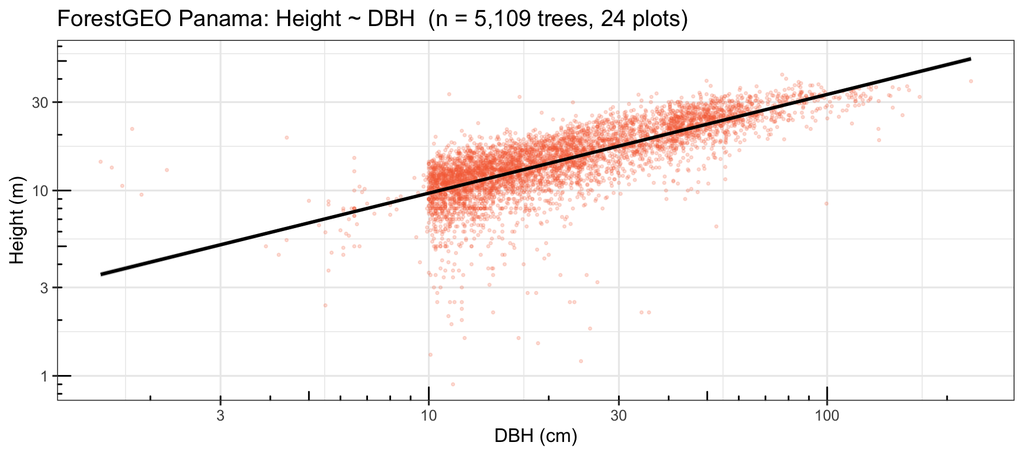

```r
fgeo |>
  filter(!is.na(TreeHt_m), DBH_cm > 0, TreeHt_m > 0) |>
  ggplot(aes(x = DBH_cm, y = TreeHt_m)) +
  geom_point(alpha = 0.2, size = 0.6, color = "#f46d43") +
  geom_smooth(method = "lm", color = "black", linewidth = 1) +
  scale_x_log10(labels = comma) + scale_y_log10(labels = comma) +
  annotation_logticks() +
  labs(x = "DBH (cm)", y = "Height (m)",
       title = "ForestGEO Panama: Height ~ DBH  (n = 5,109 trees, 24 plots)")
```

**Unit note:** DBH is stored in mm in the source file; converted to cm here. `HOM` ranges 0.3–4.8 m; buttressed trees measured above buttress.

## 3.9 NEON ForestAGB — National Ecological Observatory Network

```r
neon_sites_all <- c("BART","BLAN","CLBJ","DELA","DSNY","GRSM","GUAN","HARV",
                    "JERC","KONZ","LENO","MLBS","ORNL","OSBS","RMNP","SCBI",
                    "SERC","STEI","TALL","TREE","UKFS","UNDE","YELL")
neon_all <- lapply(neon_sites_all, function(s) {
  read_csv(file.path(dirname(knitr::current_input(dir = TRUE)),
           "data/raw/neon_forest_agb/biomass", paste0(s, "_biomass.csv")),
           show_col_types = FALSE)
}) |> bind_rows()

neon_sc <- read_csv(
  file.path(dirname(knitr::current_input(dir = TRUE)),
            "data/raw/neon_forest_agb/sitecoordinates.csv"),
  show_col_types = FALSE
)

kable(data.frame(
  Metric = c("Total measurement rows","Unique individuals","Unique species",
             "NEON sites with biomass files","Sites in coord table (full network)",
             "Years","DBH range (cm)","Height range (m)",
             "AGB range — Chojnacky (kg)","AGB range — Jenkins (kg)",
             "Allometric methods","License","Citation"),
  Value = c(
    format(nrow(neon_all), big.mark=","),
    format(length(unique(neon_all$individualID)), big.mark=","),
    format(length(unique(neon_all$scientificName[!is.na(neon_all$scientificName)])), big.mark=","),
    length(neon_sites_all),
    nrow(neon_sc),
    paste0(min(neon_all$year, na.rm=TRUE), "\u20132023"),
    paste0(round(min(neon_all$stemDiameter, na.rm=TRUE),1), "\u2013",
           round(max(neon_all$stemDiameter, na.rm=TRUE),1)),
    paste0(round(min(neon_all$height, na.rm=TRUE),1), "\u2013",
           round(max(neon_all$height, na.rm=TRUE),1)),
    paste0(round(min(neon_all$AGBChojnacky, na.rm=TRUE),2), "\u2013",
           format(round(max(neon_all$AGBChojnacky, na.rm=TRUE),0), big.mark=",")),
    if ("AGBJenkins" %in% names(neon_all))
      paste0(round(min(neon_all$AGBJenkins, na.rm=TRUE),2), "\u2013",
             format(round(max(neon_all$AGBJenkins, na.rm=TRUE),0), big.mark=","))
    else "Not in files",
    "Chojnacky et al. 2014; Jenkins et al. 2003",
    "CC0 1.0",
    "Atkins JW et al. (2024). NEONForestAGBv2. Figshare doi:10.6084/m9.figshare.25625352.v1"
  ),
  stringsAsFactors = FALSE
), caption = "NEON ForestAGB profile (23 sites with ingested biomass files)")
```

NEON ForestAGB profile (23 sites with ingested biomass files)

| Metric | Value |
| --- | --- |
| Total measurement rows | 194,704 |
| Unique individuals | 70,749 |
| Unique species | 374 |
| NEON sites with biomass files | 23 |
| Sites in coord table (full network) | 35 |
| Years | 2014–2023 |
| DBH range (cm) | 0–187 |
| Height range (m) | 0.1–122 |
| AGB range — Chojnacky (kg) | 0–38,202 |
| AGB range — Jenkins (kg) | 0–39,077 |
| Allometric methods | Chojnacky et al. 2014; Jenkins et al. 2003 |
| License | CC0 1.0 |
| Citation | Atkins JW et al. (2024). NEONForestAGBv2. Figshare doi:10.6084/m9.figshare.25625352.v1 |

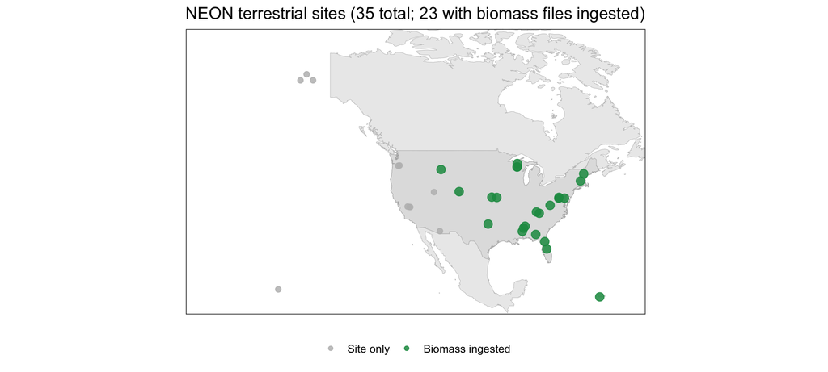

```r
neon_sc_clean <- neon_sc |>
  filter(!is.na(X), !is.na(Y)) |>
  mutate(has_biomass = siteID %in% neon_sites_all)

ggplot() +
  geom_polygon(data = map_data("usa"),
               aes(x = long, y = lat, group = group),
               fill = "grey88", color = "grey70", linewidth = 0.2) +
  geom_polygon(data = map_data("world") |>
                 filter(region %in% c("Canada","Mexico","Puerto Rico")),
               aes(x = long, y = lat, group = group),
               fill = "grey92", color = "grey75", linewidth = 0.15) +
  geom_point(data = neon_sc_clean,
             aes(x = X, y = Y,
                 color = has_biomass, size = has_biomass),
             alpha = 0.85) +
  scale_color_manual(values = c("TRUE" = "#1a9850", "FALSE" = "#bdbdbd"),
                     labels = c("TRUE" = "Biomass ingested", "FALSE" = "Site only")) +
  scale_size_manual(values  = c("TRUE" = 3.2, "FALSE" = 2),
                    guide   = "none") +
  coord_fixed(1.3, xlim = c(-175, -60), ylim = c(17, 72)) +
  labs(title = "NEON terrestrial sites (35 total; 23 with biomass files ingested)",
       x = NULL, y = NULL, color = NULL) +
  theme(axis.text = element_blank(), axis.ticks = element_blank(),
        panel.grid = element_blank(), legend.position = "bottom")
```

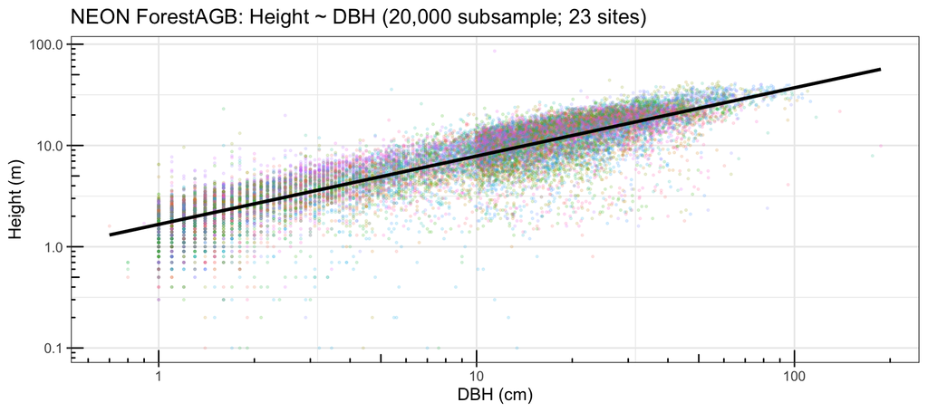

```r
neon_all |>
  filter(!is.na(stemDiameter), !is.na(height), stemDiameter > 0, height > 0) |>
  sample_n(min(20000, n())) |>
  ggplot(aes(x = stemDiameter, y = height, color = siteID)) +
  geom_point(alpha = 0.15, size = 0.5, show.legend = FALSE) +
  geom_smooth(method = "lm", color = "black", linewidth = 1.1,
              se = TRUE, aes(group = 1)) +
  scale_x_log10(labels = comma) + scale_y_log10(labels = comma) +
  annotation_logticks() +
  labs(x = "DBH (cm)", y = "Height (m)",
       title = paste0("NEON ForestAGB: Height ~ DBH (20,000 subsample; ",
                      length(neon_sites_all), " sites)"))
```

```r
shenkin_path <- file.path(dirname(knitr::current_input(dir = TRUE)),
                          "data/raw/shenkin/shenkin_etal_2020_crown_dimensions.csv")
shenkin <- read_csv(shenkin_path, show_col_types = FALSE)

kable(data.frame(
  Metric = c("Total trees", "Unique plots", "Unique species", "Unique families",
             "Region", "Elevation range (m asl)",
             "Lat range (°)", "Lon range (°)",
             "DBH range (cm)", "Tree height range (m)",
             "Crown radius range (m)", "Crown depth range (m)",
             "Crown surface area range (m²)", "Crown volume range (m³)",
             "Citation (DOI UNVERIFIED)"),
  Value = c(
    format(nrow(shenkin), big.mark = ","),
    length(unique(shenkin$plot)),
    length(unique(shenkin$species)),
    length(unique(shenkin$family)),
    paste(unique(shenkin$region), collapse = ", "),
    paste0(round(min(shenkin$`ele_asl (m)`, na.rm = TRUE), 0), "–",
           round(max(shenkin$`ele_asl (m)`, na.rm = TRUE), 0)),
    paste0(round(min(shenkin$lat, na.rm = TRUE), 3), " to ",
           round(max(shenkin$lat, na.rm = TRUE), 3)),
    paste0(round(min(shenkin$lon, na.rm = TRUE), 3), " to ",
           round(max(shenkin$lon, na.rm = TRUE), 3)),
    paste0(round(min(shenkin$DBH, na.rm = TRUE), 1), "–",
           round(max(shenkin$DBH, na.rm = TRUE), 1)),
    paste0(round(min(shenkin$`tree_height (m)`, na.rm = TRUE), 1), "–",
           round(max(shenkin$`tree_height (m)`, na.rm = TRUE), 1)),
    paste0(round(min(shenkin$`crown_radius  (m)`, na.rm = TRUE), 2), "–",
           round(max(shenkin$`crown_radius  (m)`, na.rm = TRUE), 2)),
    paste0(round(min(shenkin$`crown_depth (m)`, na.rm = TRUE), 2), "–",
           round(max(shenkin$`crown_depth (m)`, na.rm = TRUE), 2)),
    paste0(round(min(shenkin$`crown_surface_area  (m^2)`, na.rm = TRUE), 1), "–",
           round(max(shenkin$`crown_surface_area  (m^2)`, na.rm = TRUE), 0)),
    paste0(round(min(shenkin$`crown_volume  (m^3)`, na.rm = TRUE), 1), "–",
           round(max(shenkin$`crown_volume  (m^3)`, na.rm = TRUE), 0)),
    "Shenkin A et al. (2020) New Phytologist 226:1579–1592; doi:10.1111/nph.16523"
  ),
  stringsAsFactors = FALSE
), caption = "Shenkin et al. 2020 — Andean crown dimensions profile")
```

| Metric | Value |
| --- | --- |
| Total trees | 1,153 |
| Unique plots | 20 |
| Unique species | 278 |
| Unique families | 96 |
| Region | Peru, Ghana, Brazil |
| Elevation range (m asl) | 215–3537 |
| Lat range (°) | -14.83 to 7.301 |
| Lon range (°) | -71.632 to -1.15 |
| DBH range (cm) | 9.5–123.5 |
| Tree height range (m) | 2–44.5 |
| Crown radius range (m) | 0.27–17.69 |
| Crown depth range (m) | 0.7–24.1 |
| Crown surface area range (m²) | 1–2556 |
| Crown volume range (m³) | 0.1–8520 |
| Citation (DOI UNVERIFIED) | Shenkin A et al. (2020) New Phytologist 226:1579–1592; doi:10.1111/nph.16523 |

### 3.10.1 Geographic distribution of sampling points

```r
library(leaflet)

shenkin_pts <- shenkin |>
  filter(!is.na(lat), !is.na(lon)) |>
  mutate(
    ele   = `ele_asl (m)`,
    label = paste0(plot, "<br>", species, "<br>Elevation: ", ele, " m asl",
                   "<br>DBH: ", round(DBH, 1), " cm",
                   "<br>Height: ", round(`tree_height (m)`, 1), " m",
                   "<br>Crown radius: ", round(`crown_radius  (m)`, 2), " m")
  )

# colour by elevation band
pal_ele <- colorNumeric(palette = "RdYlBu", domain = shenkin_pts$ele, reverse = TRUE)

leaflet(shenkin_pts) |>
  addProviderTiles(providers$Esri.WorldTopoMap) |>
  addCircleMarkers(
    ~lon, ~lat,
    radius      = 4,
    color       = ~pal_ele(ele),
    fillColor   = ~pal_ele(ele),
    fillOpacity = 0.85,
    opacity     = 0.9,
    popup       = ~label,
    group       = "Individual trees"
  ) |>
  addLegend(
    pal      = pal_ele,
    values   = ~ele,
    title    = "Elevation (m asl)",
    position = "bottomright"
  ) |>
  addLayersControl(
    overlayGroups = "Individual trees",
    options       = layersControlOptions(collapsed = FALSE)
  )
```

[interactive chart not shown]

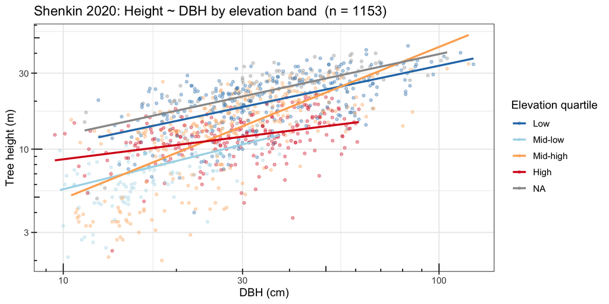

```r
shenkin |>
  filter(!is.na(DBH), !is.na(`tree_height (m)`), DBH > 0, `tree_height (m)` > 0) |>
  mutate(ele_band = cut(`ele_asl (m)`,
                        breaks = quantile(`ele_asl (m)`, probs = c(0, 0.25, 0.5, 0.75, 1),
                                          na.rm = TRUE),
                        labels = c("Low","Mid-low","Mid-high","High"),
                        include.lowest = TRUE)) |>
  ggplot(aes(x = DBH, y = `tree_height (m)`, color = ele_band)) +
  geom_point(alpha = 0.35, size = 1.2) +
  geom_smooth(method = "lm", se = FALSE, linewidth = 1) +
  scale_x_log10(labels = comma) + scale_y_log10(labels = comma) +
  annotation_logticks() +
  scale_color_brewer(palette = "RdYlBu", direction = -1, na.value = "grey60") +
  labs(x = "DBH (cm)", y = "Tree height (m)", color = "Elevation quartile",
       title = paste0("Shenkin 2020: Height ~ DBH by elevation band  (n = ",
                      nrow(shenkin), ")"))
```

## 3.11 Datasets not yet acquired (require download/registration)

```r
pending <- data.frame(
  Dataset = c(
    "Zanne et al. 2009 — Global wood density",
    "Poorter et al. 2012 — Biomass allocation",
    "Chave et al. 2014 — Pantropical AGB equations",
    "TRY Plant Trait Database",
    "FRED Fine Root Ecology Database",
    "GlobAllomeTree (FAO)"
  ),
  Citation_note = c(
    "Zanne AE et al. (2009) Global wood density. Dryad doi:10.5061/dryad.234 — DOI VERIFIED",
    "Poorter H et al. (2012) Biomass allocation. New Phytol 193:30–50 — cite needs DOI verification",
    "Chave J et al. (2014) Pantropical allometry. Global Change Biol — cite needs DOI verification",
    "Kattge J et al. (2020) TRY — a global database. Global Change Biol — cite needs verification",
    "Iversen CM et al. FRED. Ecosphere — cite needs verification",
    "FAO GlobAllomeTree — web portal, no single citable paper"
  ),
  Access = c(
    "datadryad.org/stash/dataset/doi:10.5061/dryad.234 — free download",
    "New Phytologist online supplement — manual download",
    "BIOMASS package implements equations internally",
    "try-db.org — free but requires registration + data request",
    "roots.ornl.gov — free download",
    "globallometree.org — free, no account needed"
  ),
  Priority = c("HIGH — needed for AGB estimation","HIGH — biomass partitioning",
               "MEDIUM — equations in BIOMASS package","MEDIUM — broad trait coverage",
               "LOW — roots only","LOW — equations only, no raw data"),
  stringsAsFactors = FALSE
)
kable(pending, caption = "Datasets not yet ingested — acquisition plan")
```

Datasets not yet ingested — acquisition plan

| Dataset | Citation_note | Access | Priority |
| --- | --- | --- | --- |
| Zanne et al. 2009 — Global wood density | Zanne AE et al. (2009) Global wood density. Dryad doi:10.5061/dryad.234 — DOI VERIFIED | datadryad.org/stash/dataset/doi:10.5061/dryad.234 — free download | HIGH — needed for AGB estimation |
| Poorter et al. 2012 — Biomass allocation | Poorter H et al. (2012) Biomass allocation. New Phytol 193:30–50 — cite needs DOI verification | New Phytologist online supplement — manual download | HIGH — biomass partitioning |
| Chave et al. 2014 — Pantropical AGB equations | Chave J et al. (2014) Pantropical allometry. Global Change Biol — cite needs DOI verification | BIOMASS package implements equations internally | MEDIUM — equations in BIOMASS package |
| TRY Plant Trait Database | Kattge J et al. (2020) TRY — a global database. Global Change Biol — cite needs verification | try-db.org — free but requires registration + data request | MEDIUM — broad trait coverage |
| FRED Fine Root Ecology Database | Iversen CM et al. FRED. Ecosphere — cite needs verification | roots.ornl.gov — free download | LOW — roots only |
| GlobAllomeTree (FAO) | FAO GlobAllomeTree — web portal, no single citable paper | globallometree.org — free, no account needed | LOW — equations only, no raw data |

# 4 Data volume summary

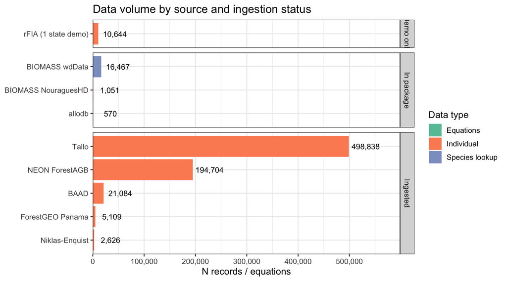

```r
# read ForestGEO Panama if not already in memory
if (!exists("fgeo")) {
  fgeo <- read_csv(
    file.path(dirname(knitr::current_input(dir = TRUE)),
              "data/raw/forestgeo_panama/TreeHeightDataSmallPlotsCombined_2024_08_05.csv"),
    show_col_types = FALSE)
}
# read NEON row count
neon_nrow <- 194704L   # pre-profiled; avoid re-reading all 84MB here

vol <- data.frame(
  Source = c("BAAD","Niklas-Enquist","Tallo","ForestGEO Panama",
             "NEON ForestAGB",
             "rFIA (1 state demo)","BIOMASS wdData","allodb","BIOMASS NouraguesHD"),
  N = c(21084, 2626, nrow(tallo), nrow(fgeo),
        neon_nrow,
        nrow(fiaRI$TREE), nrow(wdData), nrow(equations), nrow(NouraguesHD)),
  Type = c("Individual","Individual","Individual","Individual",
           "Individual",
           "Individual","Species lookup","Equations","Individual"),
  Status = c("Ingested","Ingested","Ingested","Ingested",
             "Ingested",
             "Demo only","In package","In package","In package")
)

ggplot(vol, aes(x=reorder(Source,N), y=N, fill=Type)) +
  geom_col() +
  geom_text(aes(label=format(N, big.mark=",")), hjust=-0.1, size=3.5) +
  coord_flip() +
  scale_y_continuous(labels=comma, expand=expansion(mult=c(0,0.2))) +
  scale_fill_brewer(palette="Set2") +
  facet_grid(Status ~ ., scales="free_y", space="free_y") +
  labs(x=NULL, y="N records / equations", fill="Data type",
       title="Data volume by source and ingestion status")
```

# 5 Key decisions for merging

1. **Unit harmonization required before merge:**
   - rFIA: DIA in inches → cm, HT in feet → m, DRYBIO in lbs/acre → kg/plant (requires TPA)
   - Niklas-Enquist: already kg dry weight and metres
   - BAAD: already kg and metres (SI throughout)
   - allodb: equations output in g, lbs, or metric tonnes — conversion factors are in `output_units_CF` column
2. **Taxonomy harmonization:** all sources use different taxon string formats. BAAD has `speciesMatched`; rFIA uses USDA `SPCD` codes; Niklas-Enquist uses free text; allodb uses `equation_taxa`. A single backbone (TPL, TNRS, or GBIF) is required.
3. **Data type distinction:** `allodb` and `BIOMASS` contain *equations*, not raw measurements. They should be used to *predict* biomass from DBH/height, not as independent observations of the same individuals.
4. **Pseudoreplication / stand-level data:** rFIA `DRYBIO_AG` is in lbs/acre (plot-level expansion), not per-tree dry weight. Use `DRYBIO_AG * (1/TPA_UNADJ)` to convert to per-tree lbs, then × 0.4536 to kg.